# WarwickLove

## 7.6 Topic-Word Association

- Topic coherence vs exclusivity

```r
topicQuality(finfit1,documents=result1$documents)
```

```
##  [1] -132.2994 -138.4701 -154.2877 -145.6156 -124.7948 -124.8778 -171.8749
##  [8] -154.6247 -126.7349 -149.2418 -154.8598 -115.0595 -141.1769 -166.6170
## [15] -146.0726 -157.1035 -191.8264 -147.4208 -159.4014 -131.3572 -160.4665
##  [1] 9.608174 9.608435 9.602494 9.608219 9.608406 9.601090 9.596258 9.606823
##  [9] 9.608143 9.608372 9.607883 9.608217 9.608372 9.608534 9.601848 9.608530
## [17] 9.607908 9.608623 9.608426 9.608605 9.608565
```

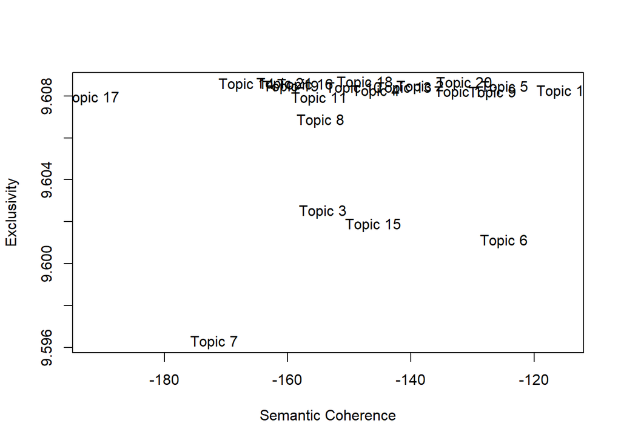

- Topic Proportion

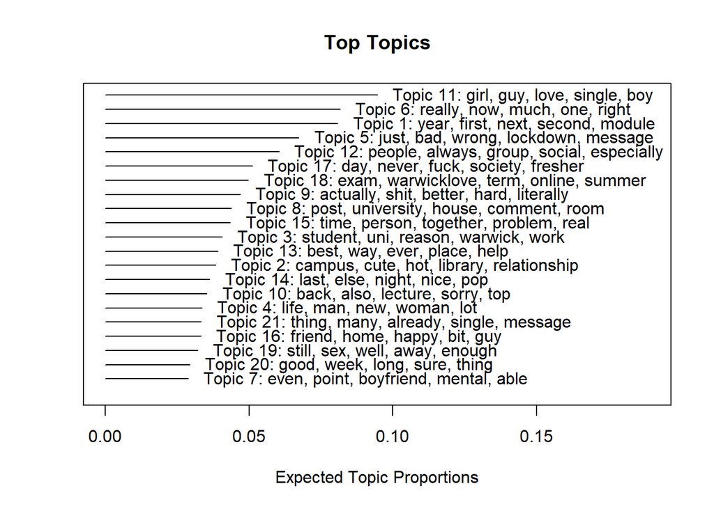

```r
# topic distribution and top 5 word association
plot.STM(finfit1, "summary", n=5)
```

- We see that topic 11 has the highest proportion to the corpus (which is about Love!), followed by topic 6, 1, 5, and 12.
- As a result, overall they’re related to relationship (friends or couple), studying, and the COVID-19 epidemic.

```r
labelTopics(finfit1, topics=c(11,6,1,5,12), n=10)
```

```
## Topic 11 Top Words:
##       Highest Prob: girl, guy, love, single, boy, warwickfession, today, always, really, thing
##       FREX: girl, love, guy, today, boy, single, warwickfession, always, thing, message
##       Lift: today, girl, love, boy, guy, warwickfession, single, always, really, thing
##       Score: today, girl, guy, love, boy, single, warwickfession, always, library, cute
## Topic 6 Top Words:
##       Highest Prob: really, now, much, one, right, month, maybe, advice, thing, wrong
##       FREX: now, right, month, really, one, much, maybe, advice, single, relationship
##       Lift: right, month, now, maybe, one, much, really, advice, wrong, thing
##       Score: right, really, now, much, one, month, advice, maybe, wrong, single
## Topic 1 Top Words:
##       Highest Prob: year, first, next, second, module, third, advice, many, literally, now
##       FREX: year, second, first, next, third, module, advice, many, literally, idea
##       Lift: first, year, second, third, next, module, advice, many, literally, now
##       Score: third, year, next, module, second, first, advice, many, literally, now
## Topic 5 Top Words:
##       Highest Prob: just, bad, wrong, lockdown, message, many, thing, really, much, reason
##       FREX: just, wrong, lockdown, bad, message, many, reason, idea, thing, work
##       Lift: lockdown, wrong, just, bad, message, many, thing, really, reason, much
##       Score: lockdown, just, bad, wrong, message, many, thing, really, reason, much
## Topic 12 Top Words:
##       Highest Prob: people, always, group, social, especially, many, bad, idea, thing, reason
##       FREX: people, group, especially, always, social, many, idea, bad, reason, thing
##       Lift: group, especially, people, social, always, many, idea, bad, thing, reason
##       Score: especially, people, always, group, social, many, bad, idea, thing, reason
```

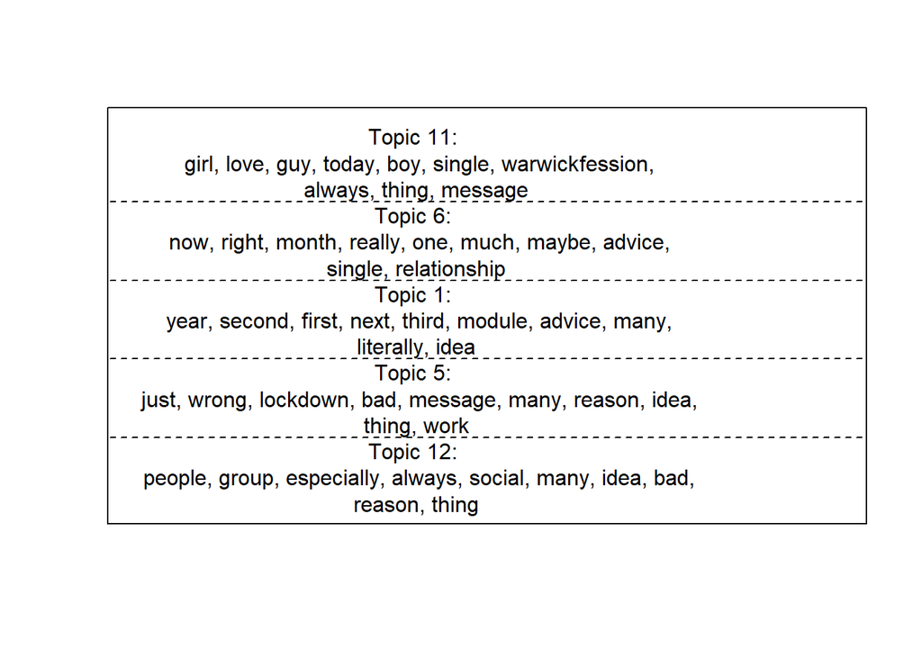

```r
plot.STM(finfit1, "labels", topics=c(11,6,1,5,12), label="frex", n=10, width=60)
```

- Top words per topic

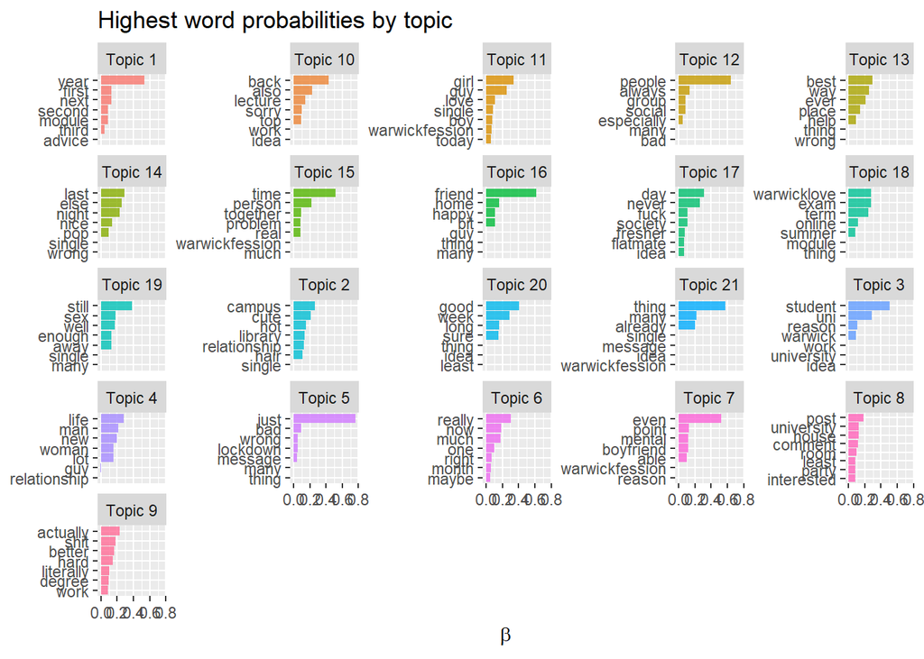

```r
beta <- tidytext::tidy(finfit1)

options(repr.plot.width=7, repr.plot.height=8, repr.plot.res=100)

beta %>%
  group_by(topic) %>%
  top_n(7, beta) %>%
  ungroup() %>%
  mutate(topic = paste0("Topic ", topic),
         term = reorder_within(term, beta, topic)) %>%
  ggplot(aes(term, beta, fill = as.factor(topic))) +
  geom_col(alpha = 0.8, show.legend = FALSE) +
  facet_wrap(~ topic, scales = "free_y") +
  coord_flip() +
  scale_x_reordered() +
  labs(x = NULL, y = expression(beta),
       title = "Highest word probabilities by topic")
```

```r
ggsave("topic_words_2.jpg",width = 9, height = 6, device= "jpg", dpi=300,scale = 1.3)
```

- Let’s create a shortcut representation for each topic e.g., T1, T2.

```r
topic_labels = {}
for (i in 1:21){
  print(i)
  labels = paste0("T",i)
  topic_labels = append(topic_labels,labels)
}
```

```
## [1] 1
## [1] 2
## [1] 3
## [1] 4
## [1] 5
## [1] 6
## [1] 7
## [1] 8
## [1] 9
## [1] 10
## [1] 11
## [1] 12
## [1] 13
## [1] 14
## [1] 15
## [1] 16
## [1] 17
## [1] 18
## [1] 19
## [1] 20
## [1] 21
```

## 7.7 Topic and Effect Estimation

- Previously, we have seen topic proportions. However, we now would like to see how the topics impact popularity. This will help an admin or posters generate the contents that would grab more attention in the community.
- Let’s fit the model

```r
effect1 = stm::estimateEffect(~ popularity + comments + shares + love +
                             wow + care + sad + angry + like_haha + anger + joy +
                             trust + hour + image_group,
                              stmobj = finfit1,
                              metadata = result1$meta)

effect1_sum = summary(effect1)
effect1_sum$tables
```

```
## [[1]]
##                 Estimate   Std. Error     t value     Pr(>|t|)
## (Intercept)  0.079985024 0.0053475606 14.95729170 2.392296e-49
## popularity   0.026274542 0.0653704144  0.40193323 6.877532e-01
## comments    -0.091750701 0.0449366267 -2.04177990 4.123434e-02
## shares      -0.001090803 0.0594628440 -0.01834427 9.853651e-01
## love        -0.319049794 0.0967305571 -3.29833512 9.805193e-04
## wow          0.315409883 0.1100934238  2.86492937 4.191272e-03
## care         0.021222084 0.0556720104  0.38119845 7.030749e-01
## sad          0.039149043 0.0706719680  0.55395434 5.796389e-01
## angry        0.062059456 0.1333709031  0.46531480 6.417296e-01
## like_haha   -0.030802124 0.0698414910 -0.44102901 6.592142e-01
## anger       -0.093796100 0.0290071614 -3.23354978 1.231870e-03
## joy         -0.118447071 0.0320412296 -3.69670804 2.211384e-04
## trust        0.114149839 0.0567350955  2.01197932 4.428445e-02
## hour         0.001081133 0.0003427037  3.15471823 1.617627e-03
## image_group -0.019947275 0.0093447678 -2.13459293 3.285073e-02
##
## [[2]]
##                  Estimate   Std. Error    t value     Pr(>|t|)
## (Intercept)  0.0340666070 0.0019038552 17.8934863 4.049614e-69
## popularity  -0.0626340015 0.0243446293 -2.5728057 1.012106e-02
## comments     0.0409919175 0.0163995423  2.4995769 1.247120e-02
## shares      -0.0203422408 0.0236619620 -0.8597022 3.900012e-01
## love         0.0992769027 0.0484141346  2.0505768 4.036873e-02
## wow         -0.0105784250 0.0275651852 -0.3837603 7.011751e-01
## care         0.0174829789 0.0259150375  0.6746268 4.999492e-01
## sad         -0.1252763709 0.0261660349 -4.7877476 1.743388e-06
## angry       -0.0483141566 0.0306518200 -1.5762247 1.150477e-01
## like_haha    0.0792304668 0.0374394013  2.1162322 3.438244e-02
## anger        0.0464991052 0.0126834526  3.6661236 2.492326e-04
## joy         -0.0205986723 0.0118789286 -1.7340514 8.298072e-02
## trust       -0.1451585782 0.0190215283 -7.6312784 2.845601e-14
## hour         0.0007835038 0.0001303598  6.0103180 2.005157e-09
## image_group -0.0030342502 0.0046720905 -0.6494417 5.160877e-01
##
## [[3]]
##                  Estimate   Std. Error     t value     Pr(>|t|)
## (Intercept)  4.190186e-02 0.0026397968 15.87313733 3.506824e-55
## popularity   9.848502e-02 0.0400998425  2.45599524 1.408882e-02
```

[output cut: 322 more lines]

```
## (Intercept)  2.609707e-02 3.846255e-04 67.8506033 0.000000e+00
## popularity   2.845014e-03 3.698197e-03  0.7692977 4.417589e-01
## comments    -5.362623e-03 2.405053e-03 -2.2297320 2.581674e-02
## shares      -9.362520e-03 3.911802e-03 -2.3934030 1.673556e-02
## love         1.663405e-02 7.835193e-03  2.1229916 3.381159e-02
## wow         -7.269679e-03 4.805762e-03 -1.5127005 1.304293e-01
## care         1.633260e-02 5.325122e-03  3.0670845 2.175036e-03
## sad         -1.916220e-02 4.658486e-03 -4.1133970 3.971777e-05
## angry       -4.998406e-03 5.713413e-03 -0.8748545 3.817020e-01
## like_haha   -1.340040e-02 6.081576e-03 -2.2034418 2.761652e-02
## anger        1.086116e-02 2.128695e-03  5.1022638 3.501038e-07
## joy         -5.270746e-03 1.936459e-03 -2.7218479 6.517994e-03
## trust        1.223018e-02 3.438445e-03  3.5568926 3.793173e-04
## hour        -3.998184e-05 2.377261e-05 -1.6818449 9.267161e-02
## image_group  5.729450e-04 7.223185e-04  0.7932027 4.277036e-01
```

- Let’s visualize.

```
## [1] 1
```

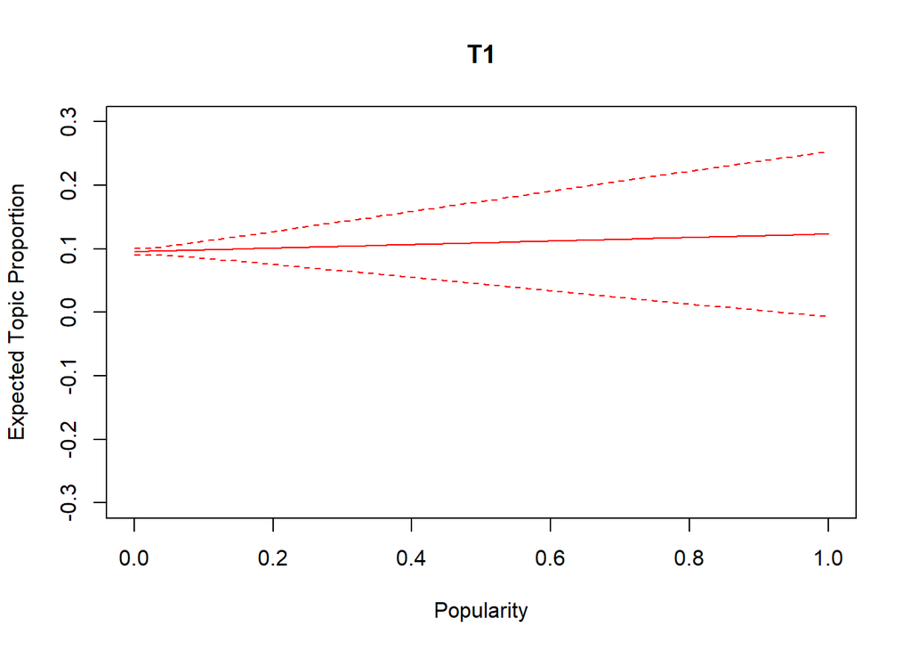

```
## [1] 2
```

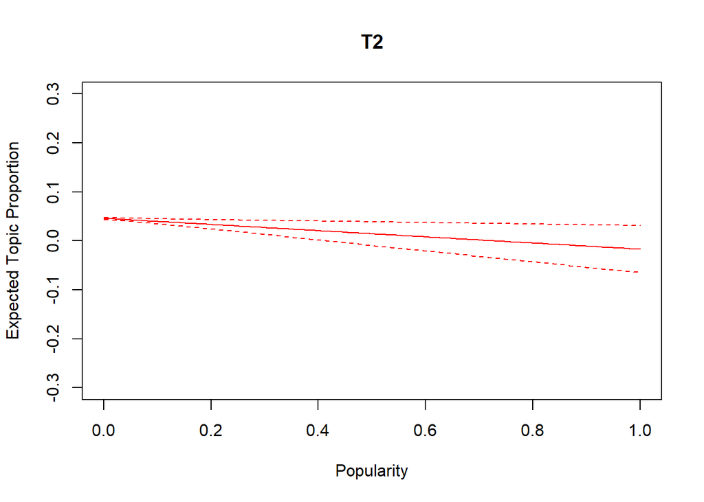

```
## [1] 3
```

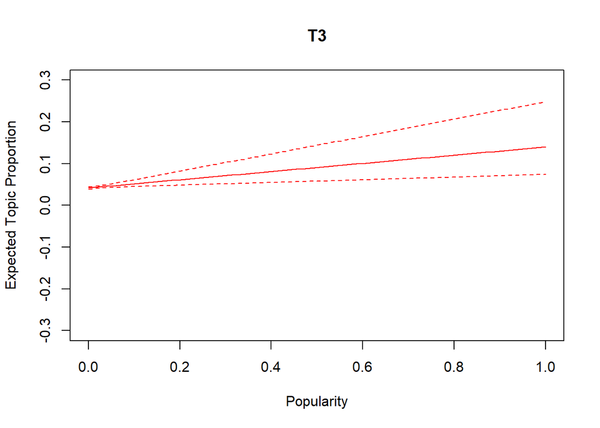

```
## [1] 4
```

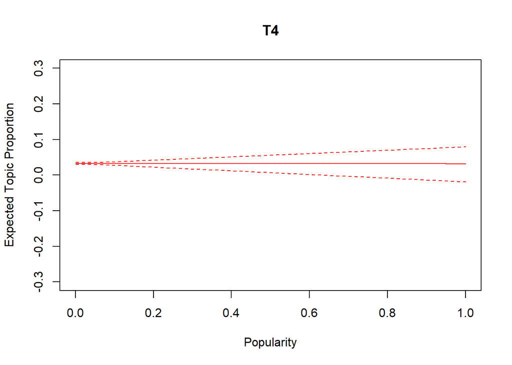

```
## [1] 5
```

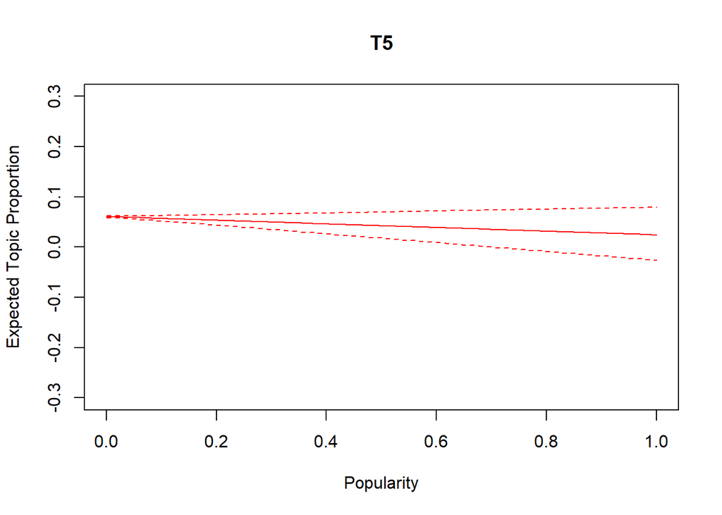

```
## [1] 6
```

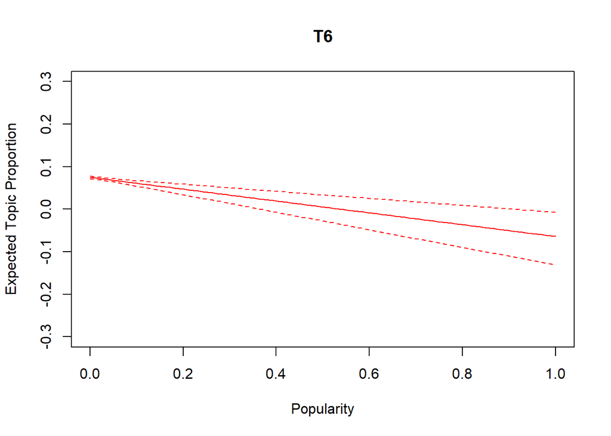

```
## [1] 7
```

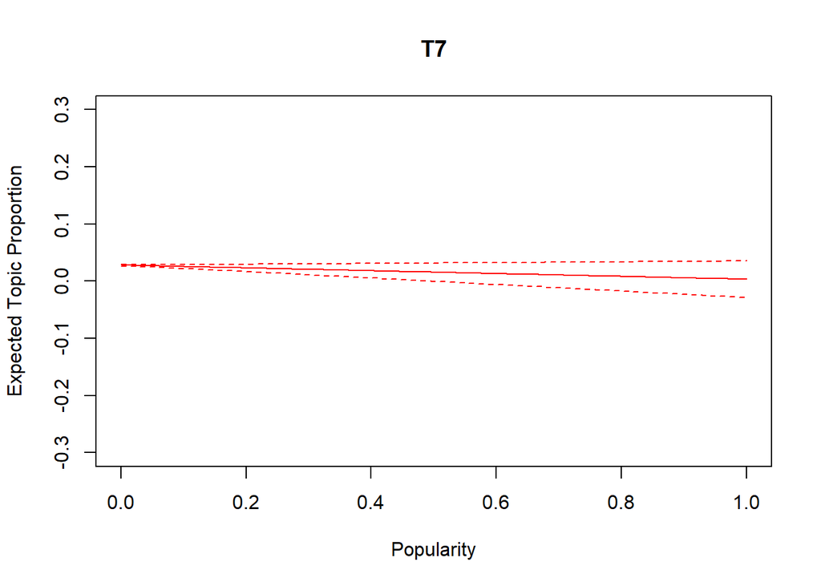

```
## [1] 8
```

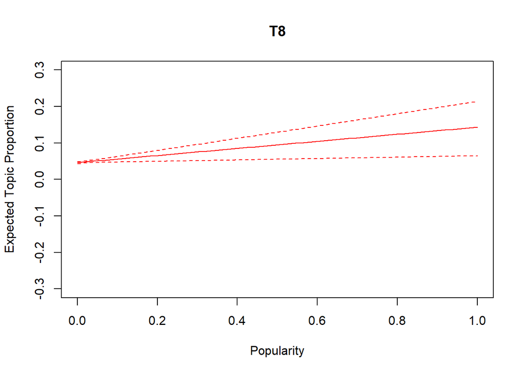

```
## [1] 9
```

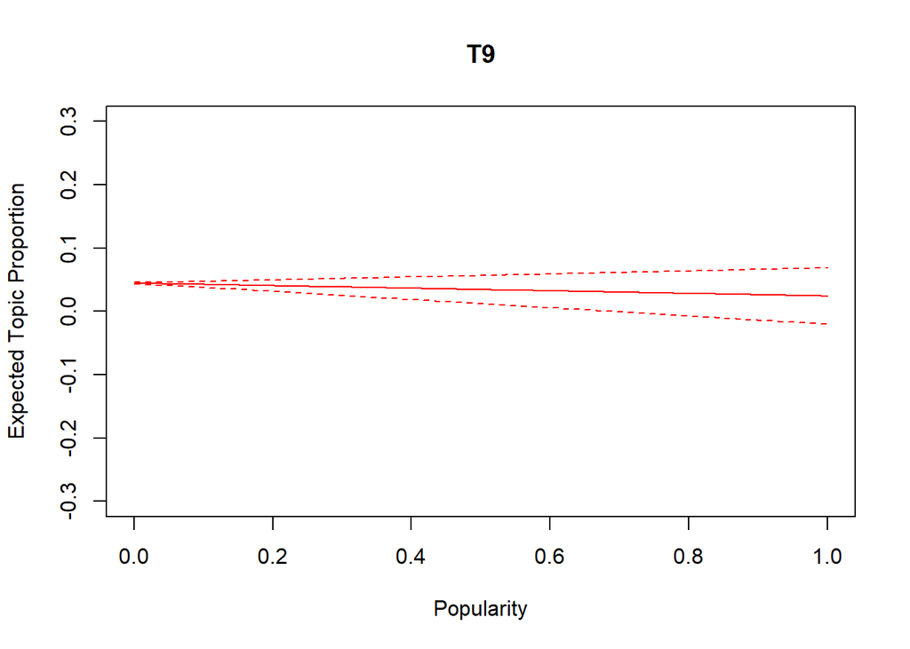

```
## [1] 10
```

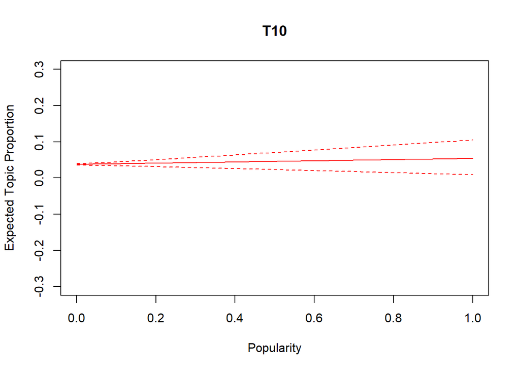

```
## [1] 11
```

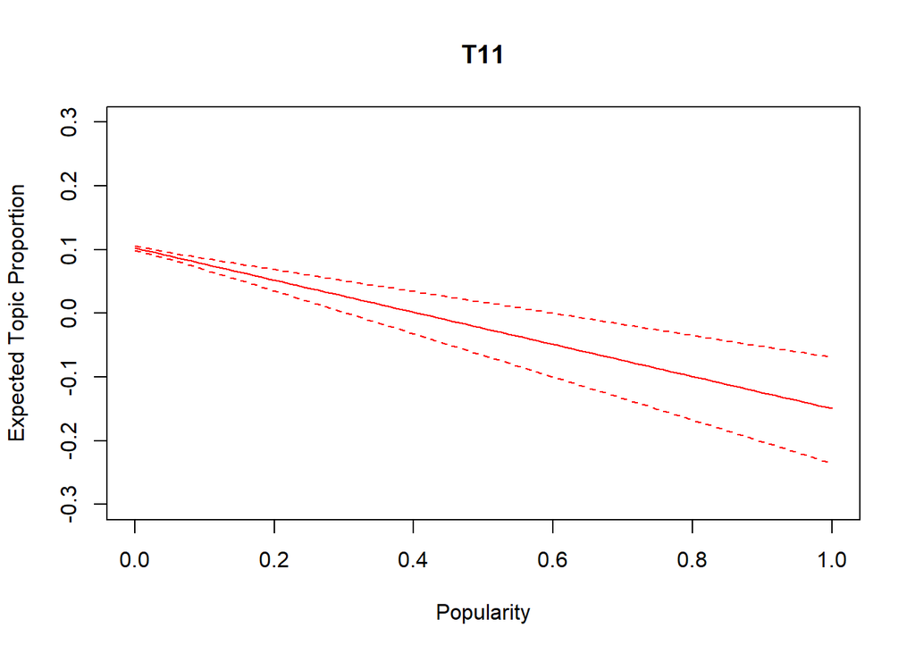

```
## [1] 12
```

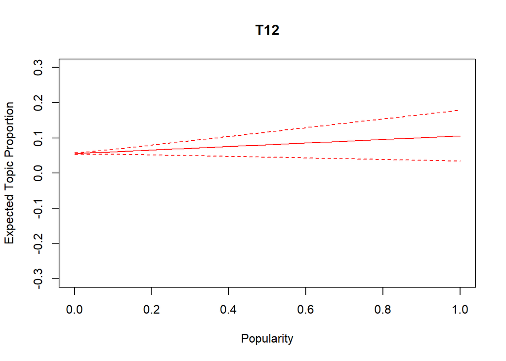

```
## [1] 13
```

[9 more figures not shown]

```r
for(i in 1:21){

   print(i)

    plot(effect1, covariate = "popularity",
         topics = i,
         model = finfit1, method = "continuous",
     # For this plotting we get the uper quantile
     # and low quantile of the price
     xlab = "Popularity",
     ylim = c(-0.3,0.3),
     main = topic_labels[i],
     printlegend = FALSE,
     custom.labels =topic_labels[i],
     labeltype = "custom")

}
```